# Predicting Palmetto Species with Binary Logistic Regression

Utilizing binary logistic regression to predict the species of two dominant palmetto species. Comparing two models and evaluating their performance using repeated cross-validation.

Binary Logistic Regression

Machine Learning

Predictive Modeling

Wrangling

Visualization

Author

Natalie Smith

Published

March 7, 2024

# 1 Overview:

The palmetto data examines the survival, growth, and biomass estimates of two dominant palmetto species, *Serenoa repens* and *Sabal etonia*, in south Florida from 1981 to 2017, recorded at 5-year intervals. The dataset encompasses various variables, but for this analysis, we will focus on canopy height, length, and width, as well as green leaves.

We aim to create two models with different predictor variables and the better-performing model will be selected. We will then evaluate the success of the chosen model in correctly classifying a plant species.

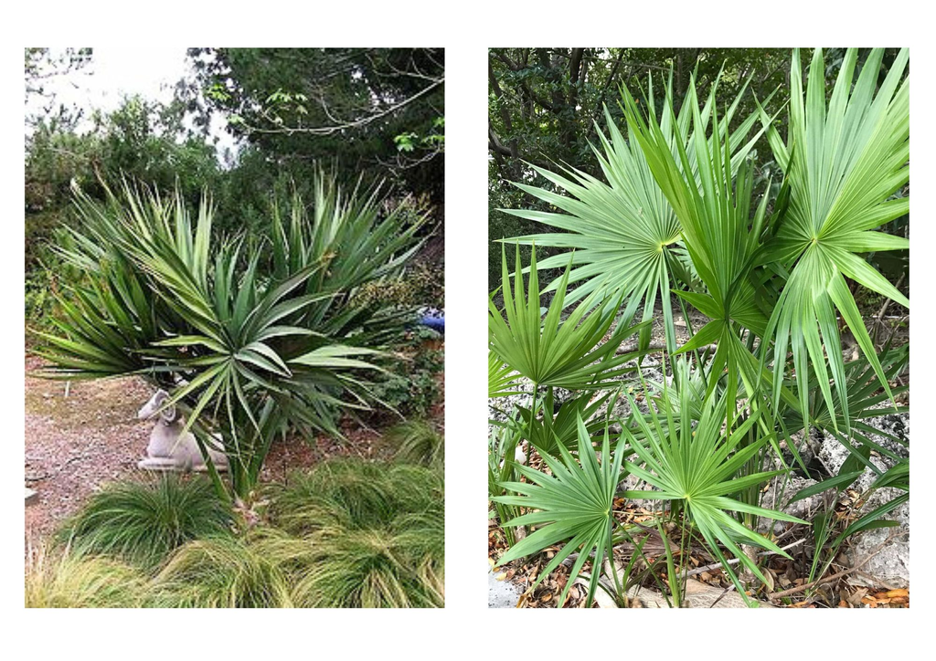

Left: Sabal etonia, Right: Serenoa repens

# 2 Exploratory Plots:

First we want to explore differences in the two species based on canopy height, canopy length, canopy width, and green leaves.

### 2.0.1 Add Libraries:

```r
library(tidyverse)
library(here)
library(tidymodels)
library(ggplot2)
library(patchwork)
library(broom)
library(kableExtra)
```

### 2.0.2 Import and Wrangle Data:

```r
#pull in the data
p_df <- read.csv(here("portfolio/palms/data/palmetto.csv"))

#clean data
palmetto <- p_df %>%
  select(species,height,length,width,green_lvs) %>%
  mutate(species=as_factor(species)) %>%
  drop_na()
```

### 2.0.3 Plots:

```r
#Species Boxplot ~ Green Leaves
leaves_plot <- ggplot(palmetto,
                     aes(x =as.factor(species),
                         y = green_lvs)) +
  geom_boxplot(fill = "#ADD8E6", color = "#2E75B6",
               alpha = 0.8,
               outlier.color = "#FF5733",
               outlier.shape = 16,
               outlier.size = 1) +
  scale_x_discrete(labels =
                     expression(italic("S.repens"),
                                italic("S.etonia"))) +
  labs(x = "Species", y = "Green Leaves") +
  theme_minimal() +
  theme(
    axis.title.y = element_text(size = 10),
    axis.title.x = element_text(size = 10),
    axis.text = element_text(size = 10),
    legend.position = "none"
  )
# leaves_plot
```

```r
#Species Boxplot ~ Canopy Height
height_plot <- ggplot(palmetto,
                     aes(x =as.factor(species),
                         y = height)) +
  geom_boxplot(fill = "#ADD8E6", color = "#2E75B6",
               alpha = 0.8,
               outlier.color = "#FF5733",
               outlier.shape = 16,
               outlier.size = 1) +
  scale_x_discrete(labels =
                     expression(italic("S.repens"),
                                italic("S.etonia"))) +
  labs(x = "Species", y = "Canopy Height") +
  theme_minimal() +
  theme(
    axis.title.y = element_text(size = 10),
    axis.title.x = element_text(size = 10),
    axis.text = element_text(size = 10),
    legend.position = "none"
  )
# height_plot
```

```r
#Species Boxplot ~ Canopy Length
length_plot <- ggplot(palmetto,
                     aes(x =as.factor(species),
                         y = length)) +
  geom_boxplot(fill = "#ADD8E6", color = "#2E75B6",
               alpha = 0.8,
               outlier.color = "#FF5733",
               outlier.shape = 16,
               outlier.size = 1) +
  scale_x_discrete(labels =
                     expression(italic("S.repens"),
                                italic("S.etonia"))) +
  labs(x = "Species", y = "Canopy Length") +
  theme_minimal() +
  theme(
    axis.title.y = element_text(size = 10),
    axis.title.x = element_text(size = 10),
    axis.text = element_text(size = 10),
    legend.position = "none"
  )
# length_plot
```

```r
#Species Boxplot ~ Canopy Width
width_plot <- ggplot(palmetto,
                     aes(x =as.factor(species),
                         y = width)) +
  geom_boxplot(fill = "#ADD8E6", color = "#2E75B6",
               alpha = 0.8,
               outlier.color = "#FF5733",
               outlier.shape = 16,
               outlier.size = 1) +
  scale_x_discrete(labels =
                     expression(italic("S.repens"),
                                italic("S.etonia"))) +
  labs(x = "Species", y = "Canopy Width") +
  theme_minimal() +
  theme(
    axis.title.y = element_text(size = 10),
    axis.title.x = element_text(size = 10),
    axis.text = element_text(size = 10),
    legend.position = "none"
  )
# width_plot
```

### 2.0.4 Combined Plot:

```r
plot1 <- leaves_plot +
  theme(axis.text.y = element_text(size = 8)) +
  theme(axis.title.x = element_blank())

plot2 <- height_plot +
  theme(axis.text.y = element_text(size = 8)) +
  theme(axis.title.x = element_blank())

plot3 <- length_plot +
  theme(axis.text.y = element_text(size = 8)) +
  theme(axis.title.x = element_blank())

plot4 <- width_plot +
  theme(axis.text.y = element_text(size = 8)) +
  theme(axis.title.x = element_blank())
```

Based on our visual exploration, we can see that while the species are very similar, there are species differentiation observed when examining green leaves and canopy length.

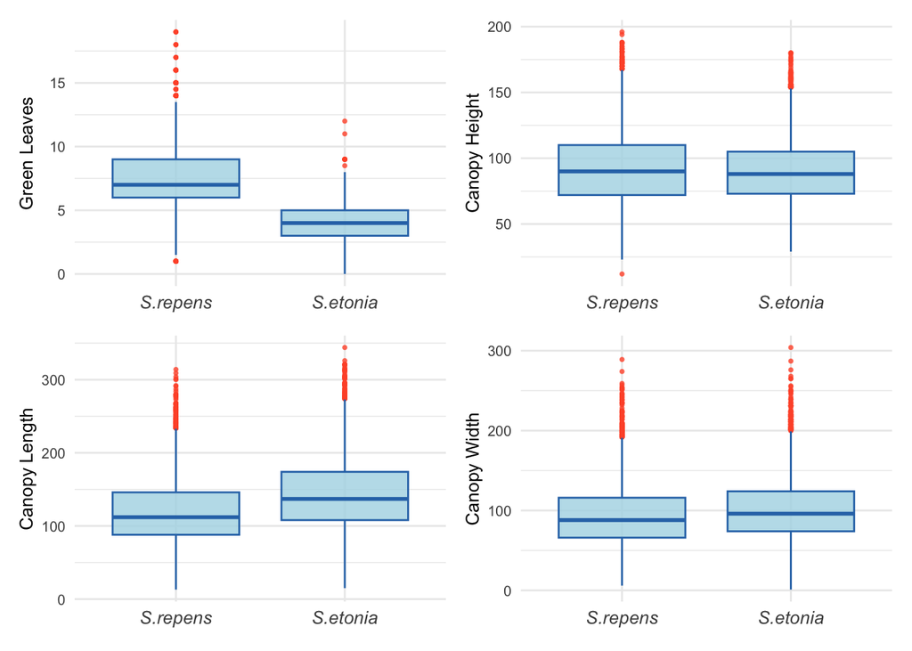

Figure 1: Comparison of species Sabal etonia and Serenoa repens reveals differences and similarities in predictor variables. In combined boxplots, (counter-clockwise from left) we observe a higher count of green leaves in S. repens. In canopy length, we see greater canopy length in S. etonia. Canopy width and height exhibit similar counts.

```r
combinedplot <- plot1 + plot2 + plot3 + plot4
combinedplot
```

# 3 Models:

To determine whether a plant is *Serenoa repens* or *Sabal etonia*, we need to conduct a binary logistic regression using several predictor variables. We will perform the analysis twice comparing the following models:

- Model 1: The log odds of plant type using plant height, canopy length, canopy width, and green leaves as predictor variables.
- Model 2: The log odds of plant type using plant height, canopy width, and green leaves (excluding canopy length for this model).

Note that *S. repens* = speices 1 and *S. etonia* = species 2.

```r
# Define formulas:
f1 <- species ~ height + length + width + green_lvs
f2 <- species ~ height + width + green_lvs

# BLR:
blr1 <- glm(formula = f1, data = palmetto, family = binomial)

blr2 <- glm(formula = f2, data = palmetto, family = binomial)

# # Summarize:
# summary(blr1)
# summary(blr2)
```

# 4 Repeated Cross Validation:

Next we need to utilize repeated cross-validation (ten-fold cross-validation) using tidymodels for both models.

```r
# Set seed
set.seed(10101)

# Create folds:
surv_folds <- vfold_cv(palmetto, v = 10, repeats = 10)

# Default:
blr_mdl <- logistic_reg() %>%
  set_engine('glm')

# Workflows:
blr_wf1 <- workflow() %>%
  add_model(blr_mdl) %>%
  add_formula(f1)

blr_wf2 <- workflow() %>%
  add_model(blr_mdl) %>%
  add_formula(f2)

#apply to folded datasetls:
blr_fit_folds1 <- blr_wf1 %>%
  fit_resamples(surv_folds)

blr_fit_folds2 <- blr_wf2 %>%
  fit_resamples(surv_folds)

# blr_fit_folds1
# blr_fit_folds2

# # Metrics:
# collect_metrics(blr_fit_folds1)
# collect_metrics(blr_fit_folds2)
```

The metrics show:

- F1 has a mean accuracy of approximately 92% and a mean ROC of approximately 97%.
- F2 has a mean accuracy of approximately 90% and a mean ROC of approximately 96%.

Based on these metrics, F1 appears to be the better performing model, as it has higher values for both accuracy and ROC.

# 5 Train on Full Dataset:

Now that we have decided the F1 is the better predicting model, we want to train the model on the entire dataset.

```r
blr_fit_full <- blr_mdl %>%
  fit(formula = f1, data = palmetto)

palmetto_predict <- palmetto %>%
  mutate(predict(blr_fit_full,new_data = .))
```

The results of the BLR model are presented below:

```r
# Broom::Tidy
tidy_output <- tidy(blr_fit_full)

# Create kable table with title
coef_table <- kable(tidy_output, align = "c")%>%
  kable_styling()

coef_table
```

| term | estimate | std.error | statistic | p.value |
| --- | --- | --- | --- | --- |
| (Intercept) | 3.2266851 | 0.1420708 | 22.71180 | 0 |
| height | -0.0292173 | 0.0023061 | -12.66984 | 0 |
| length | 0.0458233 | 0.0018661 | 24.55600 | 0 |
| width | 0.0394434 | 0.0021000 | 18.78227 | 0 |
| green_lvs | -1.9084747 | 0.0388634 | -49.10728 | 0 |

Figure 2: Binary logistic regression results for the F1 model applied to the entire Palmetto dataset.

To assess the model’s accuracy for identifying plant species correctly, we need to introduce a conditional argument: if the predicted probability is greater than or equal to 50%, the plant is classified as species 1; otherwise, it is classified as species 2. We can then construct a table illustrating the count of correctly and incorrectly classified plants from the original dataset by the model, as well as a column displaying the percentage of plants correctly classified.

```r
# Calculate predicted species based on probabilities and 50% cutoff
palmetto_predict_prob<- augment(blr_fit_full, new_data = palmetto, type.predict = 'response') %>%
    mutate(predicted_species = ifelse(.pred_1 >= 0.5, "1", "2")) %>%
  select(predicted_species, everything())
```

```r
# Create a table of observed and predicted species

# results_table <- table(palmetto_predict_prob %>%
#   select(predicted_species, species))
#
# tidy(results_table)

species <- c('S. Repens', 'S. Etonia')
predict_correct <- c(5548,5701)
predict_incorrect <- c(564,454)
percent_correct <- c(91,93)

# Create the data frame
species_correct <- data.frame(species, predict_correct, predict_incorrect, percent_correct)

#kable it
species_correct_kable <- kable(species_correct, align = "c") %>%
  kable_styling()

species_correct_kable
```

| species | predict_correct | predict_incorrect | percent_correct |
| --- | --- | --- | --- |
| S. Repens | 5548 | 564 | 91 |
| S. Etonia | 5701 | 454 | 93 |

# 6 Reference:

Abrahamson, W.G. 2019. Survival, growth and biomass estimates of two dominant palmetto species of south-central Florida from 1981 - 2017, ongoing at 5-year intervals ver 1. Environmental Data Initiative. https://doi.org/10.6073/pasta/f2f96ec76fbbd4b9db431c79a770c4d5